# Reproducible Research: Peer Assessment 1

Joshua Paolo Acilo

## INTRODUCTION

It is now possible to collect a large amount of data about personal movement using activity monitoring devices such as a Fitbit, Nike Fuelband, or Jawbone Up. These type of devices are part of the “quantified self” movement - a group of enthusiasts who take measurements about themselves regularly to improve their health, to find patterns in their behavior, or because they are tech geeks. But these data remain under-utilized both because the raw data are hard to obtain and there is a lack of statistical methods and software for processing and interpreting the data.

This assignment makes use of data from a personal activity monitoring device. This device collects data at 5 minute intervals through out the day. The data consists of two months of data from an anonymous individual collected during the months of October and November, 2012 and include the number of steps taken in 5 minute intervals each day.

## DATA

The data for this assignment can be downloaded from the course web site:

- Dataset: [Activity monitoring data](https://d396qusza40orc.cloudfront.net/repdata%2Fdata%2Factivity.zip)

The variables included in this dataset are:

1. *steps*: Number of steps taking in a 5-minute interval (missing values are coded as NA
2. *date*: The date on which the measurement was taken in YYYY-MM-DD format
3. *interval*: Identifier for the 5-minute interval in which measurement was taken

The dataset is stored in a comma-separated-value (CSV) file and there are a total of 17,568 observations in this dataset.

## ASSIGNMENT

This assignment will be described in multiple parts. You will need to write a report that answers the questions detailed below. Ultimately, you will need to complete the entire assignment in a single R markdown document that can be processed by knitr and be transformed into an HTML file.

Throughout your report make sure you always include the code that you used to generate the output you present. When writing code chunks in the R markdown document, always use echo = TRUE so that someone else will be able to read the code. *This assignment will be evaluated via peer assessment so it is essential that your peer evaluators be able to review the code for your analysis.*

For the plotting aspects of this assignment, feel free to use any plotting system in R (i.e., base, lattice, ggplot2)

Fork/clone the GitHub repository created for this assignment. You will submit this assignment by pushing your completed files into your forked repository on GitHub. The assignment submission will consist of the URL to your GitHub repository and the SHA-1 commit ID for your repository state.

NOTE: The GitHub repository also contains the dataset for the assignment so you do not have to download the data separately.

## Loading and preprocessing the data

The following pkgs are used:  
1. *data.table* for fread and fwrite  
2. *ggplot2* for plotting  
3. *dplyr* for piping

```r
library(data.table)
library(ggplot2)
library(dplyr)
file_url <- "https://d396qusza40orc.cloudfront.net/repdata%2Fdata%2Factivity.zip"
download.file(file_url, destfile = paste0(getwd(), '/repdata%2Fdata%2Factivity.zip'), method = "curl")
unzip("repdata%2Fdata%2Factivity.zip", exdir = "data")

# read the data into a data.table
activity_dt <- fread(input = "data/activity.csv")
```

## What is mean total number of steps taken per day?

1. Make a histogram of the total number of steps taken each day.

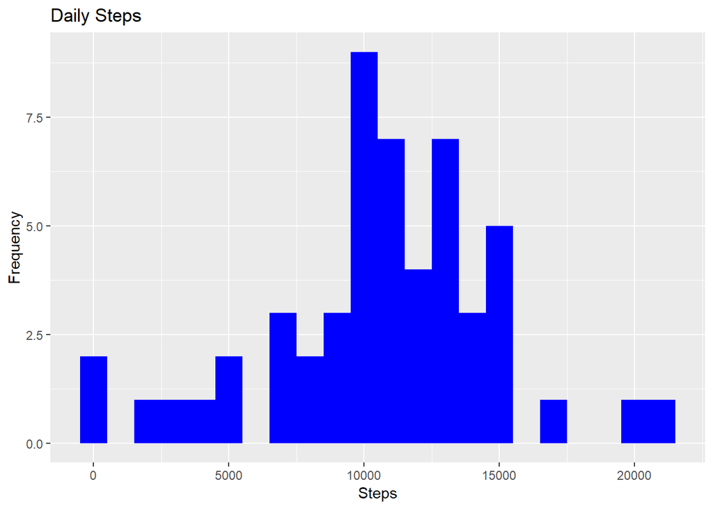

```r
# group activity by date then get the mean summary
steps_per_day <- activity_dt %>%
                 group_by(date) %>%
                 summarise(steps = sum(steps, na.rm = FALSE))

ggplot(steps_per_day, aes(x = steps)) +
       geom_histogram(fill = "blue", binwidth = 1000) +
       labs(title = "Daily Steps", x = "Steps", y = "Frequency")
```

2. Calculate and report the mean and median of the total number of steps taken per day

```r
# get the mean and median using the summarise func
# steps_per_day is already grouped by date; no need to repeat code before
# use na.rm flag as NAs are still present in the dataset
steps_per_day %>% summarise(mean_steps = mean(steps, na.rm = T),
                            median_steps = median(steps, na.rm = T))
```

```
## # A tibble: 1 x 2
##   mean_steps median_steps
##        <dbl>        <int>
## 1     10766.        10765
```

## What is the average daily activity pattern?

1. Make a time series plot (i.e. type = “l”) of the 5-minute interval (x-axis) and the average number of steps taken, averaged across all days (y-axis)

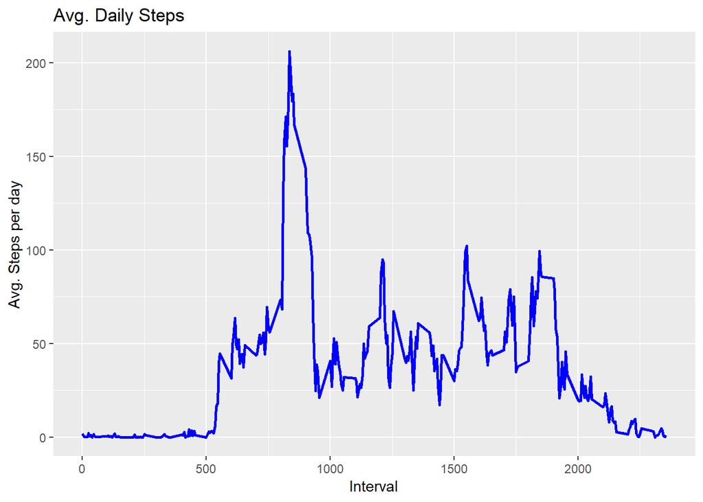

```r
# group activity by intervals then get the mean summary
# use the na.rm flag as NAs are present
interval_dt <- activity_dt %>%
               group_by(interval) %>%
               summarise(steps = mean(steps, na.rm = T))

ggplot(interval_dt, aes(x = interval , y = steps)) +
       geom_line(color = "blue", size = 1) +
       labs(title = "Avg. Daily Steps", x = "Interval", y = "Avg. Steps per day")
```

2. Which 5-minute interval, on average across all the days in the dataset, contains the maximum number of steps?

```r
# use which func to det the wanted index of the 5-min interval with max number of steps
interval_dt$interval[which(interval_dt$steps == max(interval_dt$steps))]
```

```
## [1] 835
```

## Imputing missing values

Note that there are a number of days/intervals where there are missing values (coded as NA). The presence of missing days may introduce bias into some calculations or summaries of the data.

```r
# count the number of NAs in the steps col using the is.na func then get the sum
sum(is.na(activity_dt$steps))
```

```
## [1] 2304
```

2. Devise a strategy for filling in all of the missing values in the dataset. The strategy does not need to be sophisticated. For example, you could use the mean/median for that day, or the mean for that 5-minute interval, etc.

```r
# fill all the NA values with the median of the steps column (median is zero)
activity_dt[is.na(steps), "steps"] <- activity_dt$steps %>%
                                      median(na.rm = T)
```

3. Create a new dataset that is equal to the original dataset but with the missing data filled in.

```r
# write the tidy dataset
fwrite(x = activity_dt, file = "tidy_data.csv", quote = FALSE)
```

4. Make a histogram of the total number of steps taken each day and Calculate and report the *mean* and *median* total number of steps taken per day. Do these values differ from the estimates from the first part of the assignment? What is the impact of imputing missing data on the estimates of the total daily number of steps?

```r
# do the same as before but this time the NA values are zero (the median computed before)
steps_per_day <- activity_dt %>%
                 group_by(date) %>%
                 summarise(steps = sum(steps))

# same as above; no need to specify the na.rm flag as there are no more NAs
steps_per_day %>% summarise(mean_steps = mean(steps),
                            median_steps = median(steps))
```

```
## # A tibble: 1 x 2
##   mean_steps median_steps
##        <dbl>        <int>
## 1      9354.        10395
```

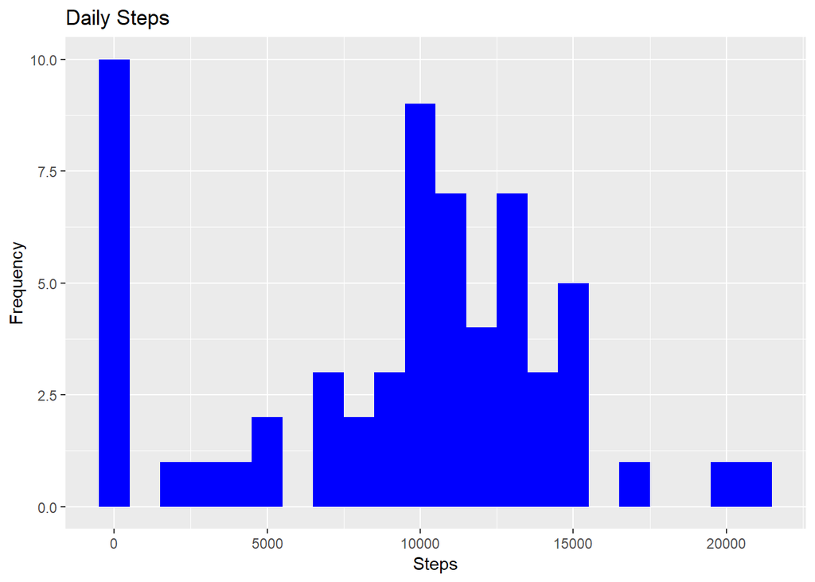

[output not shown]

```r
ggplot(steps_per_day, aes(x = steps)) +
       geom_histogram(fill = "blue", binwidth = 1000) +
       labs(title = "Daily Steps", x = "Steps", y = "Frequency")
```

## Are there differences in activity patterns between weekdays and weekends?

1. Create a new factor variable in the dataset with two levels - “weekday” and “weekend” indicating whether a given date is a weekday or weekend day.

```r
# read the activity dataset again
# mutate date column; change to POSIXct YMD date format
# mutate Day of Week column; change to weekday values
# create new column - weekday or weekend
# IF DOW is in mon-fri, DOW is weekday,
# ELSE IF DOW is in sat-sun, DOW is weekend
# chage weekday or weekend column to factor data type
activity_dt <- fread(input = "data/activity.csv")
activity_dt[, date := as.POSIXct(date, format = "%Y-%m-%d")]
activity_dt[, `Day of Week`:= weekdays(x = date)]
activity_dt[grepl(pattern = "Monday|Tuesday|Wednesday|Thursday|Friday", x = `Day of Week`), "weekday or weekend"] <- "weekday"
activity_dt[grepl(pattern = "Saturday|Sunday", x = `Day of Week`), "weekday or weekend"] <- "weekend"
activity_dt[, `weekday or weekend` := as.factor(`weekday or weekend`)]

head(activity_dt, 10)
```

```
##     steps       date interval Day of Week weekday or weekend
##  1:    NA 2012-10-01        0      Monday            weekday
##  2:    NA 2012-10-01        5      Monday            weekday
##  3:    NA 2012-10-01       10      Monday            weekday
##  4:    NA 2012-10-01       15      Monday            weekday
##  5:    NA 2012-10-01       20      Monday            weekday
##  6:    NA 2012-10-01       25      Monday            weekday
##  7:    NA 2012-10-01       30      Monday            weekday
##  8:    NA 2012-10-01       35      Monday            weekday
##  9:    NA 2012-10-01       40      Monday            weekday
## 10:    NA 2012-10-01       45      Monday            weekday
```

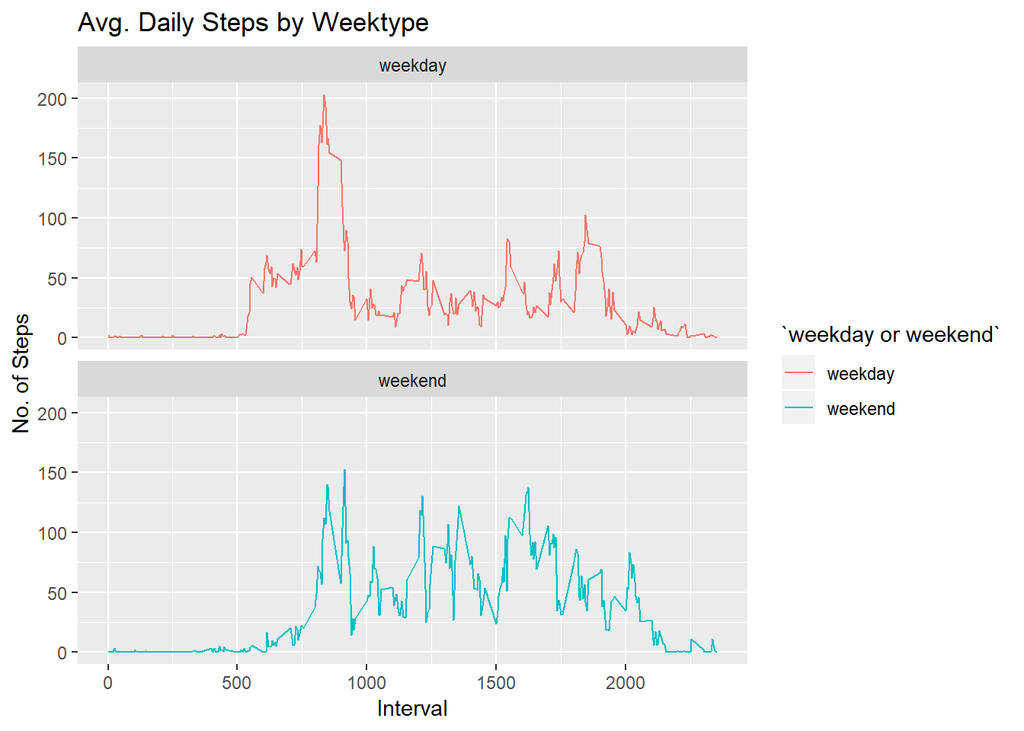

```r
# fill all the NA values with the median of the steps column (median is zero)
activity_dt[is.na(steps), "steps"] <- activity_dt$steps %>%
                                      median(na.rm = T)

# group activity by interval then by weekday or weekend
# then get the mean summary of steps
interval_dt <- activity_dt %>%
               group_by(interval, `weekday or weekend`) %>%
               summarise(steps = mean(steps))

ggplot(interval_dt , aes(x = interval , y = steps, color = `weekday or weekend`)) +
       geom_line() +
       labs(title = "Avg. Daily Steps by Weektype", x = "Interval", y = "No. of Steps") +
       facet_wrap(~ `weekday or weekend` , ncol = 1, nrow = 2)
```